# Modeling (Support Vector Machine)

Sebastian Deri

[return to overview page]

In this section, I will build a support vector machine (SVM) model to make truth and lie predictions on our statements. I turn to this technique because it is one of the popular modeling methods in “machine learning”. Kuhn & Johnson (2013, p.343) state that SVMs have become “one of the most flexible and effective machine learning tools available” since they were first developed by Vladimir Vapnik in the 1960s. Indeed, SVMs are used in countless research papers in the realm of computational social science and text analysis (e.g. Bakshy, Messing, & Adamic (2015) use an SVM for news article classification in their highly cited paper on selective news exposure on Facebook, and Wu et al. (2008) list it in their article “Top 10 algorithms in data mining”, a paper which itself has over 3,900 citations).

I’m not going to pretend to have a deep understanding of the mathematics that underlie this model (obviously I don’t). However, I will try to recapitulate the main intuitions from those, like Kuhn & Johnson (2013), who have tried to bring machine learning methods to a larger audience.

In the figure below, Kuhn & Johnson (2013, p.344) have us imagine a case where we are using two predictor variables (i.e. Predictor A and Predictor B, along the x and y axes) to predict binary outcomes (i.e. classify/separate the red circles and blue squares). In cases where these two binary outcomes are perfectly seperable, an infinite number of lines can be generated that would indeed successfully separate these two classes (left panel). For each of these individual lines, we can imagine perpendicular lines radiating outwards from both ends. The distance that each of these lines can radiate outwards before they would bump into a data point is called the “margin”. In each case, the bounds of this margin are entirely determined by those nearest abutting data points, which are called “support vectors” (because they sort of “support” the margin; and hence the name “support vector machines”). In the simplest case, it is my understanding that support vector machines essentially construct a linear model with the largest possible margin given the data points.

This strategy can then be generalized to cases of higher dimensions (e.g. defining a 2-d plane (instead of a 1-d line) to seperate binary outcomes when we have 3 predictors (instead of 2) and are thus working in three dimensions, etc). And further, of course in most cases, the two classes are not perfectly seperable. However, this problem can be dealt with by applying a penalties for each of the misclassified data points when generating maximum margin classifiers. This introduces a new parameter that we must set for our model – the cost penalty for misclassification. (There is no “correct” cost penalty. And the actual costs penalties used are usually determined through another process of training and testing that is “nested” within the training data set, which cycles through the performance of models with different cost penalties. A cost penality of 1 penalizes “hits” and “misses” equally. And larger cost penalties tend to result in more overfitting (Kuhn & Johnson, 2013, p.346-347).)

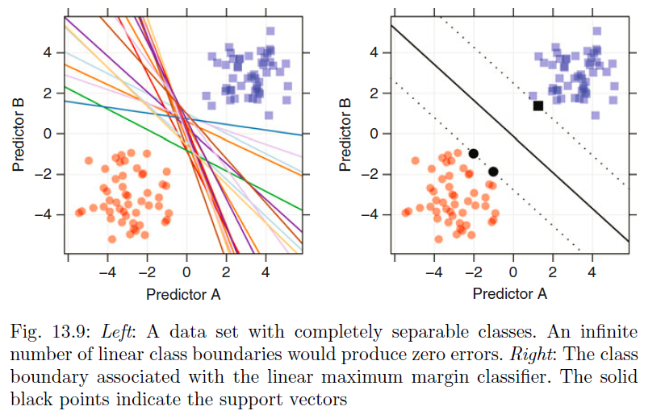

Further, we can move from creating models that produce linear classification boundaries (e.g. lines, planes, and hyperplances, etc) to models that produce non-linear classification boundaries through the use of a “kernel function”, which takes our predictor variables and applies a non-linear transformation to them. Popular non-linear kernel functions include the polynomial, radial basis, and hyperbolic tangent functions (Kuhn & Johnson, 2013, p.347). Some of these kernel functions introduce additional parameters that need to be set (e.g. we need to set a free parameter sigma, when using the radial basis function).

The different classification boundaries created by a non-linear support vector machine (which, here, uses a radial basis function) is shown below as a function of different possible values of the two tunning parameters (the cost penalty and sigma).

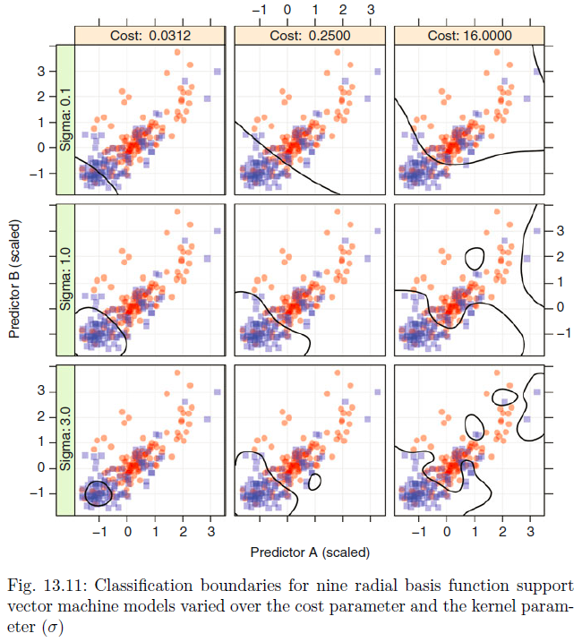

Let’s now implement a support vector machine to predict truths and lies in our dataset, using our textual features as predictors. I will implement support vector machine models with radial basis kernel functions, as I would like to take advantage of SVMs ability to produce non-linear classification boundaries.

# Packages

Let’s make sure to load all the relevant packages.

```r
# before knitting: message = FALSE, warning = FALSE
library(tidyverse) # cleaning and visualization
library(caret) # modeling
library(kernlab) # has sigest
```

# Load Data

Next, I will again load the pre-processed data, which we created earlier (see Data Cleaning & Pre-Processing). As a reminder, this dataset has a row for each of 5,004 statements, a column indicating whether that particular statement was a truth or a lie, and 90 possible predictor variables for each statement, which comes from the textual features we extracted earlier.

```r
# load pre-processed df's
load("stats_proc.Rda")

# For rendering, I'm going to cheat here and load results created when this model was first run
# For some reason, chunks that were supposed to be caches when originally run are rerunning
load("results_svm.Rda")
results <- results_svm # change the specific named (renamed at end), back to generic name
```

# EXAMPLE (Support Vector Machine, with Radial Basis Function)

As usual, let’s begin with an example. We will conduct one training-testing split and create and assess the performance of of one resultant support vector machine model, with a radial basis kernel function.

## Split Sample Into Training and Testing Sets

As with our logistic regression models, we will conduct a 50-50 training-testing split, randomly allocating one half of the statements to the training set, and the other half to the testing set using the createDataPartition function in the caret package (Kuhn, 2008).

```r
# set seed, so that statistics don't keep changing for every analysis
set.seed(2019)

# partition data in 50-50 lgocv split (create index for test set)
index_train_ex <-
  createDataPartition(y = stats_proc$stat_id,
                      p = 0.50,
                      times = 1,
                      list = FALSE)

# actually create data frame with training set (predictors and outcome together)
train_set_ex <- stats_proc[index_train_ex, ]

# actualy create data frame with test set (predictors and outcome together)
test_set_ex <- stats_proc[-index_train_ex, ]
```

## Build Model (on Training Set)

Now that the data are split, we can fit an SVM (radial basis) to the training data. We can do this by selecting the “svmRadial” model in the “train” function of the caret package (Kuhn, 2008; [Kuhn, 2019](https://topepo.github.io/caret/train-models-by-tag.html)).

Unlike with our logistic regression model, we have two free tuning parameters, which need to be set. These are our cost penalty and our sigma parameter in the radial basis function.

The default behavior of the train function for our dataset would be to run through three different cost penalties: 0.25, 0.50, and 1.0. And the default behavior of the train function for our dataset would be to select a single sigma value (rather than trying out several), by taking the mean of the multiple sigma values suggested for our dataset by the sigest function in the kernlab package. (Oddly, the default code seems to take the mean of these values, excluding the second suggestion for no apparent reason [see here for discussion](https://stats.stackexchange.com/questions/408159/what-is-the-basis-for-the-default-sigma-value-used-by-svmradial-in-caret). Thus, I override this and simply take the median of all the sigma values suggested by the sigest function). Thus, we will hold the sigma parameter constant, using the (slightly modified) value derived from the sigest function. To evaluate a more broad host of cost penalties, I will cycle through values from: 0.25, 0.5, 1, 2, and 4.

In the end, we must settle on a single value for each of the two free parameters in our model. Our sigma value is already constant, so this is done. No choices to make there. But we must select one cost penalty among our several candidates (0.25, 0.50, 1, 2, and 4). The process of selecting among different parameters is called model “tuning”. To select among the candidate cost penalty parameter values, we will conducted a nested version of testing/training process within the training dataset we are restricted to here (we will not touch the 2500 entry testing dataset we set aside earlier). For each possible parameter value (e.g. cost penalty = 0.25, cost penality = 0.50, etc), we can train a model with that parameter value on a subset of the training data and evaluate the performance of that model on another subset of the training data (essentialy a test set, within the trainin set). To create these subsets within our training data we can use the same data splitting techniques from before (i.e. cross-validation, repeated training/testing splits). For the sake of consistency, I will use the same data-splitting technique for model tuning as we used for the overall training-testing split: a 50-50, random split (i.e. the ~2500 entry training set will be further subdivide into a ~1250 entry sub-training-set training set and a ~1250 sub-training-set testing set). For each parameter value, we will actually repeat this process 3 times, and the performance of the model with that parameter value will be the average across these three rounds (the metric by which performance will be evaluated here will be overall accuracy; however other metrics could also be used like [AUC](https://en.wikipedia.org/wiki/Receiver_operating_characteristic#Area_under_the_curve)).

These model tuning process is completed below, followed by a summary of our results. As we can see in the textual output, our sigma parameter value was held constant (at sigma = 0.0057), and the cost penalty parameter that resulted in the best performance was a cost penalty of 2 (which led to an average accuracy rate of 61.3%). Thus, the svm (radial basis) model we select will have its tuning parameters set to: sigma = 0.0057, and cost penalty = 2.

```r
# note: these setting chunks are separated for reuse later

# set seed, so that statistics don't keep changing for every analysis
set.seed(2019)

# -----------------------------------------------------------------------------
# STEP 1: SELECT TUNING PARAMETERS

# part a: select cost penalty values
costs_svm <- c(0.25, 0.5, 1, 2, 4)

# part b: get suggested sigma value, for radial basis function, for this data set
# i take the median of the kernlab suggestions
# (default in caret is to take mean, excluding second suggestion)
# see: https://github.com/topepo/caret/blob/master/models/files/svmRadial.R
# and: https://stats.stackexchange.com/questions/408159/what-is-the-basis-for-the-default-sigma-value-used-by-svmradial-in-caret
sigma_svm <- median(
              kernlab::sigest(
                as.matrix(train_set_ex
                            %>% select(
                              -stat_id,
                              -grd_truth)
                          ),
                scaled = TRUE
                )
              )

# part c: save parameters in tune grid object
tune_grid_svm <- expand.grid(sigma = sigma_svm,
                             C = costs_svm)

# -----------------------------------------------------------------------------
# STEP 2: SELECT TUNING METHOD
# set up train control object, which specifies training/testing technique
train_control_svm <- trainControl(method = "LGOCV",
                                  number = 3,
                                  p = 0.50)
```

```r
# set seed, so that statistics don't keep changing for every analysis
# (applies for models which might have random parameters)
set.seed(2019)

# start timer
start_time <- Sys.time()

# -----------------------------------------------------------------------------
# STEP 3: TRAIN MODEL

# use caret "train" function to train svm
model_ex <-
  train(form = grd_truth ~ . - stat_id,
        data = train_set_ex,
        method = "svmRadial",
        tuneGrid = tune_grid_svm,
        trControl = train_control_svm,
        metric = "Accuracy") # how to select among models

# end timer
total_time <- Sys.time() - start_time
```

```r
# print out overall summary for tuning process
model_ex
```

```
## Support Vector Machines with Radial Basis Function Kernel
##
## 2504 samples
##   91 predictor
##    2 classes: 'lie', 'truth'
##
## No pre-processing
## Resampling: Repeated Train/Test Splits Estimated (3 reps, 50%)
## Summary of sample sizes: 1252, 1252, 1252
## Resampling results across tuning parameters:
##
##   C     Accuracy   Kappa
##   0.25  0.5987753  0.1975506
##   0.50  0.6054313  0.2108626
##   1.00  0.6110224  0.2220447
##   2.00  0.6134185  0.2268371
##   4.00  0.6123536  0.2247071
##
## Tuning parameter 'sigma' was held constant at a value of 0.005704987
## Accuracy was used to select the optimal model using the largest value.
## The final values used for the model were sigma = 0.005704987 and C = 2.
```

## Evaluate Model (on Testing Set)

When we evaluate the performance of our tuned model on the holdout testing set, we see that it performs well. Its overall accuracy was significantly better than chance: 63.2% [95% CI: 61.3, 65.1%]. And it performed well both in identifying truths (i.e. sensitivity: 61.9%) and identifying lies (i.e. specificity: 64.6%). (I wondered if the rate of lie detection (specificity) was significantly higher than the rate of truth detection (sensitivity); however, a two sample test for equality of proportions revealed this was not the case, X^2 = 1.76, p = 0.184.)

Finally, we can evaluate the quality of the model’s guessing. When the model made a prediction that a statement was a truth, it was correct more often than not (i.e. precision or positive predictive value: 63.6%). And when it made a prediction that a statement was a lie, it was also correct more often than not (i.e. negative predictive value: 62.9%). (Confidence intervals can easily be generated for these other four statistics as well (i.e. +/- z*(sqrt(p*(1-p)/n), where z = 1.96; I won’t calculate these for this example, but I will do so below in our full analysis.)

```r
# note: https://stats.stackexchange.com/questions/52274/how-to-choose-a-predictive-model-after-k-fold-cross-validation
# which makes clear that we retrain our final model selected after turning on ALL the training data

# make predictions
preds_ex <-
  predict(object = model_ex,
          newdata = test_set_ex,
          type = "raw")

# record model performance
conf_ex <-
  confusionMatrix(data = preds_ex,
                  reference = test_set_ex$grd_truth,
                  positive = "truth")

# print confusion matrix
conf_ex
```

```
## Confusion Matrix and Statistics
##
##           Reference
## Prediction lie truth
##      lie   807   476
##      truth 443   774
##
##                Accuracy : 0.6324
##                  95% CI : (0.6132, 0.6513)
##     No Information Rate : 0.5
##     P-Value [Acc > NIR] : <2e-16
##
##                   Kappa : 0.2648
##  Mcnemar's Test P-Value : 0.2912
##
##             Sensitivity : 0.6192
##             Specificity : 0.6456
##          Pos Pred Value : 0.6360
##          Neg Pred Value : 0.6290
##              Prevalence : 0.5000
##          Detection Rate : 0.3096
##    Detection Prevalence : 0.4868
##       Balanced Accuracy : 0.6324
##
##        'Positive' Class : truth
##
```

```r
# test whether sensitivity is better than specificity
prop.test(x = c(807, 774),
          n = c((807+443), (774+476)),
          alternative = "two.sided")
```

```
##
##  2-sample test for equality of proportions with continuity
##  correction
##
## data:  c(807, 774) out of c((807 + 443), (774 + 476))
## X-squared = 1.7619, df = 1, p-value = 0.1844
## alternative hypothesis: two.sided
## 95 percent confidence interval:
##  -0.01218583  0.06498583
## sample estimates:
## prop 1 prop 2
## 0.6456 0.6192
```